# Diagonal Case - Multiple Stocks/Ages

## 4.3 The output from the fit

Here is the fitted spline curve to the number of unmarked fish available of both stocks and ages.

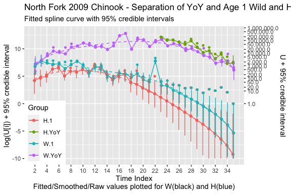

Fitted spline curve

```r
demo2.fit$plots$fit.plot
```

The separation of wild and hatchery fish is evident as well has the start of the spline for the hatchery fish.

A plot of the $logit(P)$ is

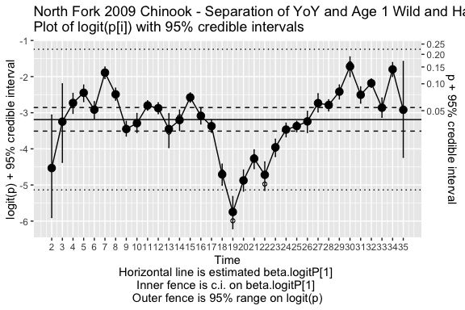

Estimates of logit(p)

```r
demo2.fit$plots$logitP.plot
```

In cases where there is no information (such as the first julian week), $BTSPAS$ has interpolated based on the distribution of catchability in the other strata and so the credible interval is very wide.

A summary of the posterior for each parameter is also available. In particular, here are the summary statistics on the posterior sample for the total number unmarked separated by wild and hatchery origin and the different ages:

```r
round(demo2.fit$summary[ grepl("Utot", row.names(demo2.fit$summary)),],1)
```

```
#>                 mean      sd      2.5%       25%       50%       75%     97.5% Rhat n.eff
#> Utot       2386940.8 84166.8 2237244.0 2327203.5 2384582.0 2437539.0 2558058.1  1.1    50
#> Utot.1       25942.0  2626.9   22200.7   24138.7   25525.5   27284.5   32443.7  1.0  1500
#> Utot.H.1      6152.0   839.7    4687.4    5553.0    6132.0    6646.5    8014.0  1.0   240
#> Utot.H.YoY  691196.5 36095.7  635368.9  667992.2  685298.0  706758.0  774673.6  1.2    24
#> Utot.W.1     19790.1  2576.2   15872.2   18034.5   19437.0   21026.2   25996.6  1.0   890
#> Utot.W.YoY 1669802.3 66913.1 1547504.9 1624302.5 1667991.5 1713981.7 1806870.2  1.0   220
#> Utot.YoY   2360998.7 83896.9 2213493.1 2301055.7 2358232.0 2411267.0 2531455.4  1.1    50
```

# 5 Wild and Hatchery Steelhead with YoY and Age 1 fish.

In this analysis we fit a diagonal time-stratified Petersen estimator separating wind from hatchery Steelhead salmon..

This differs from the Wild vs Hatchery Chinook salmon in previous sections in that all hatchery raised steelhead are marked, so there is complete separation by age and (wild/hatchery). There are 3 population of interest, Wild.YoY, Hatchery.Age1+, and Wild.Age1+.

This analysis is based on the analysis of California Junction City 2003 Steelhead data and is the example used in the Trinity River Project.

In each stratum $j$, $n1[j]$ fish are marked and released above a rotary screw trap. Of these, $m2[j]$ are recaptured in the stratum of release, i.e. the matrix of releases and recoveries is diagonal. The $n1[j]$ and $m2[j]$ establish the capture efficiency of the trap.

At the same time, $u2[j]$ unmarked fish are captured at the screw trap. These fish are a mixture of wild and hatchery raised steelhead salmon. The $u2[j]$ are separated into

- $u2.W.YoY[j]$ representing wild, YoY steelhead,
- $u2.W.1 [j]$ representing wild, age 1+ steelhead, and
- $u2.H.1 [j]$ representing hatchery, age 1+ steelhead.

## 5.1 Reading in the data

Here is an example of some raw data that is read in:

```r
demo3.data.csv <- textConnection(
"     jweek,      n1,      m2,      u2.W.YoY,      u2.W.1,      u2.H.1
          9,       0,       0,             0,          58,           0
         10,       0,       0,             0,         357,           2
         11,       0,       0,             0,         720,           0
         12,     999,       5,             0,         850,        4643
         13,    1707,      13,            11,         585,        5758
         14,    1947,      39,             0,         532,        4220
         15,    2109,       7,             0,         873,        2328
         16,     972,       1,             0,         303,        1474
         17,     687,       0,             1,         291,         875
         18,       0,       0,            33,          12,          39
         19,       0,       0,            31,         101,          15
         20,       0,       0,            11,          47,          13
         21,       0,       0,            78,          49,          26
         22,       0,       0,            46,          44,          22
         23,       0,       0,            35,          50,          59
         24,       0,       0,            30,          38,          15
         25,       0,       0,           309,          58,           8
         26,       3,       0,           278,          36,           4
         27,       0,       0,           207,          13,           2
         28,       0,       0,           196,           5,           0
         29,       0 ,      0,           613,          12,           0
         30,       0,       0,           764,          15,           0
         31,       0,       0,           556,          11,           0
         32,       0,       0,           250,          12,           0
         33,       0,       0,           106,          13,           0
         34,       0,       0,           413,          12,           0
         35,       0,       0,           995,          28,           1
         36,       0,       0,           357,          10 ,          0
         37,       0,       0,           181,           8,          27
         38,       0,       0,            53,           3,           2
         39,       0,       0,            29,           2,           0
         40,       0,       0,             3,           0,           0
         41,       0,       0,             5,           0,           0
         42,       0,       0,            14,           4,           0
         43,       0,       0,             8,          10,           0
         44,       0,       0,            19,           7,           0
         45,       0,       0,            46,           4,           0
         46,       0,       0,           229,           7,          0")

demo3.data <- read.csv(demo3.data.csv, header=TRUE, as.is=TRUE, strip.white=TRUE)

print(demo3.data)
```

```
#>    jweek   n1 m2 u2.W.YoY u2.W.1 u2.H.1
#> 1      9    0  0        0     58      0
#> 2     10    0  0        0    357      2
#> 3     11    0  0        0    720      0
#> 4     12  999  5        0    850   4643
#> 5     13 1707 13       11    585   5758
#> 6     14 1947 39        0    532   4220
#> 7     15 2109  7        0    873   2328
#> 8     16  972  1        0    303   1474
#> 9     17  687  0        1    291    875
#> 10    18    0  0       33     12     39
#> 11    19    0  0       31    101     15
#> 12    20    0  0       11     47     13
#> 13    21    0  0       78     49     26
#> 14    22    0  0       46     44     22
```

[output cut: 24 more lines]

There are several unusual features of the data set:

- Marking and releasing of steelhead took place in only a few weeks! The hierarchical model will extrapolate outside these weeks to estimate the capture rate. This is likely a very dangerous thing to do.
- There one julian week where the number of unmarked fish captured suddenly jumps by several orders of magnitude. This jump correspond to releases of hatchery fish into the system.
- Before the hatchery release, we know that all of the unmarked fish without an adipose clip are wild fish.